# Внешний курс. Блок 2: Защита ПК/Телефона

Основы информационной безопасности

Петрова А.А.

Российский университет дружбы народов, Москва, Россия

16 мая 2025

# Информация

## Докладчик

- Петрова Алевтина Александровна
- НКАбд-04-23
- Российский университет дружбы народов

## Цель

Пройти второй блок курса “Основы кибербезопасности”

## Задание

Выполнение контрольных заданий блока 2: Защита ПК/Телефона

## Вопрос 3.1.1

Шифрование диска — технология защиты информации, переводящая данные на диске в нечитаемый код, который нелегальный пользователь не сможет легко расшифровать. Соответственно, можно.

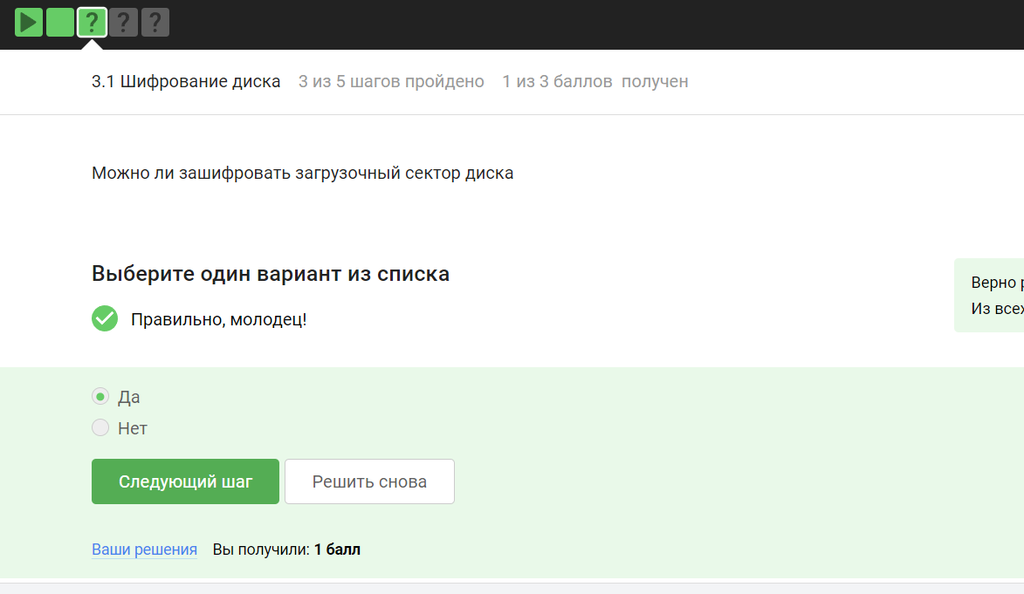

## Вопрос 3.1.2

Шифрование диска основано на симметричном шифровании

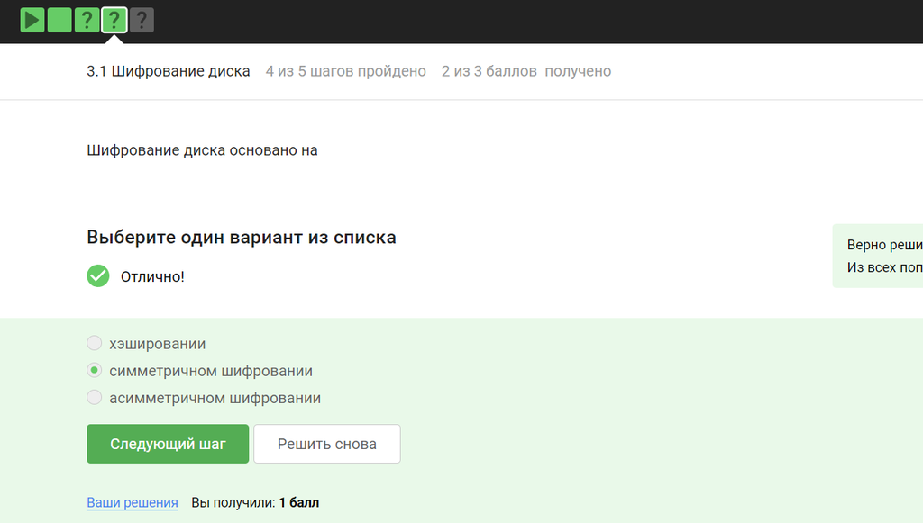

## Вопрос 3.1.3

Отмечены программы, с помощью которых можно зашифровать жесткий диск

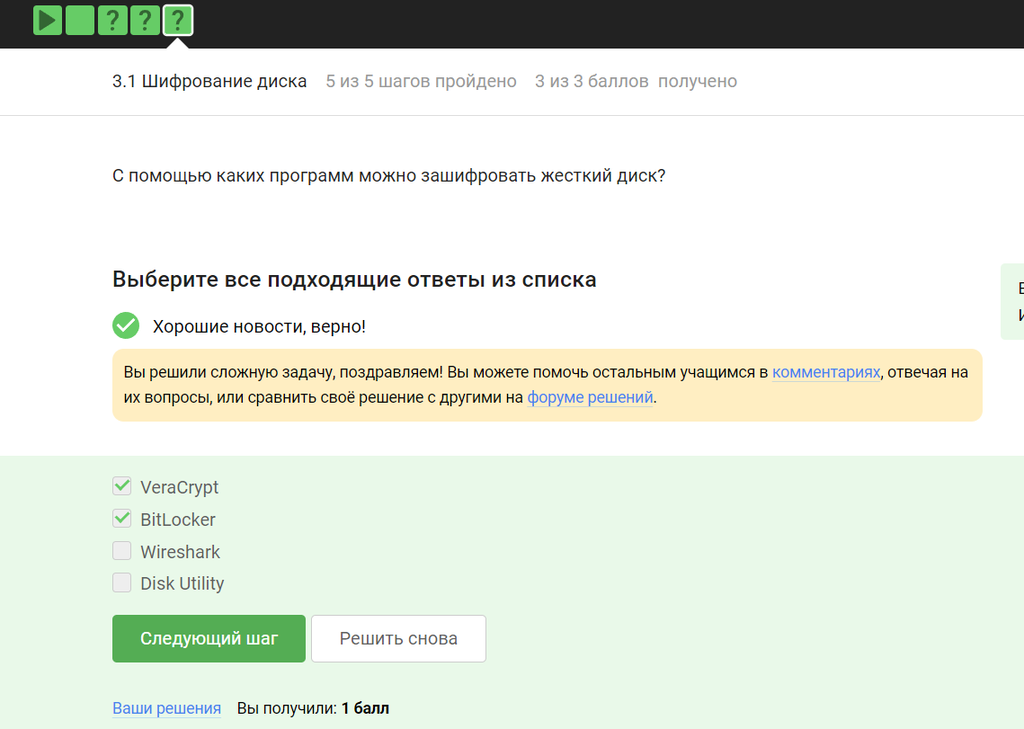

## Вопрос 3.2.1

Стойкий пароль - тот, который тяжелее подобрать, он должен быть со спец. символами и длинный

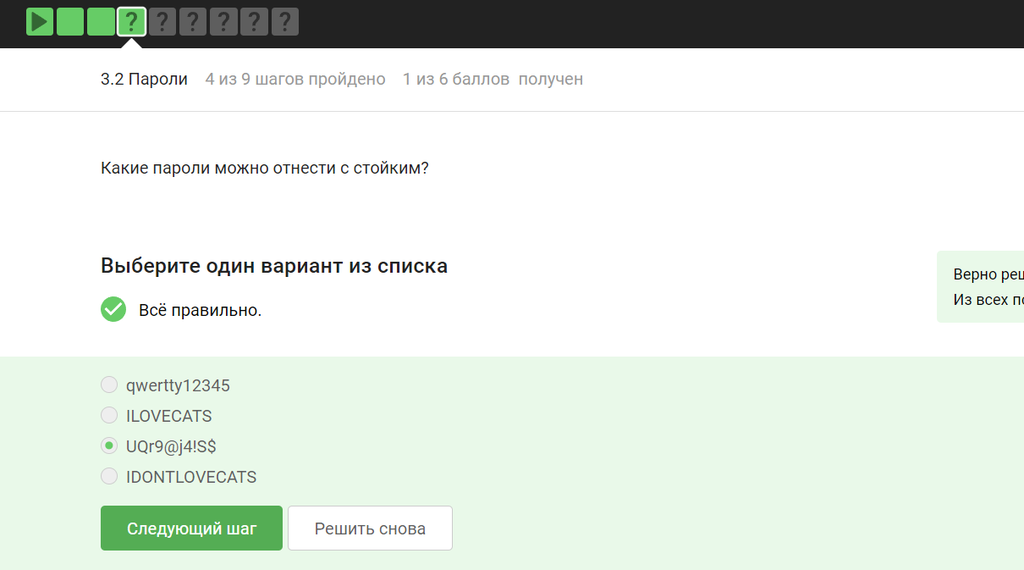

## Вопрос 3.2.2

Все варианты, кроме менеджера паролей, совершенно не надежные

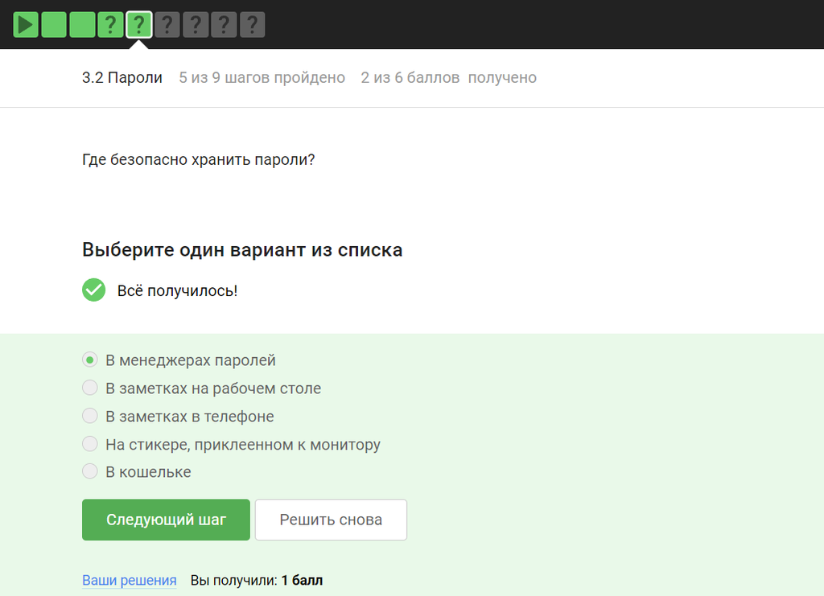

## Вопрос 3.2.3

Капча нужна для проверки на то, что за экраном “не робот”

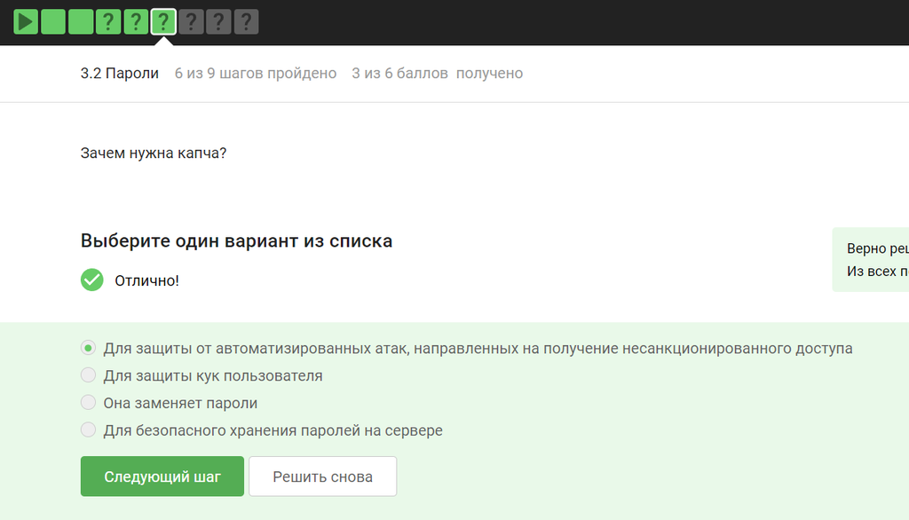

## Вопрос 3.2.4

Опасно хранить пароли в открытом виде, поэтому хранят их хэши

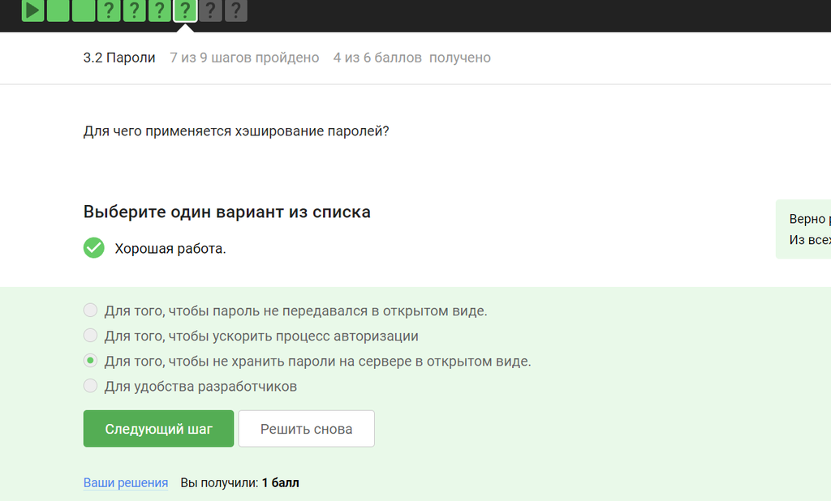

## Вопрос 3.2.5

Соль не поможет

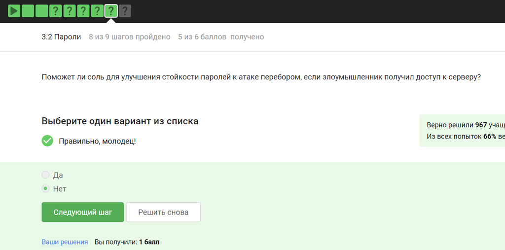

## Вопрос 3.2.6

Все приведенные меры защищают от утечек данных

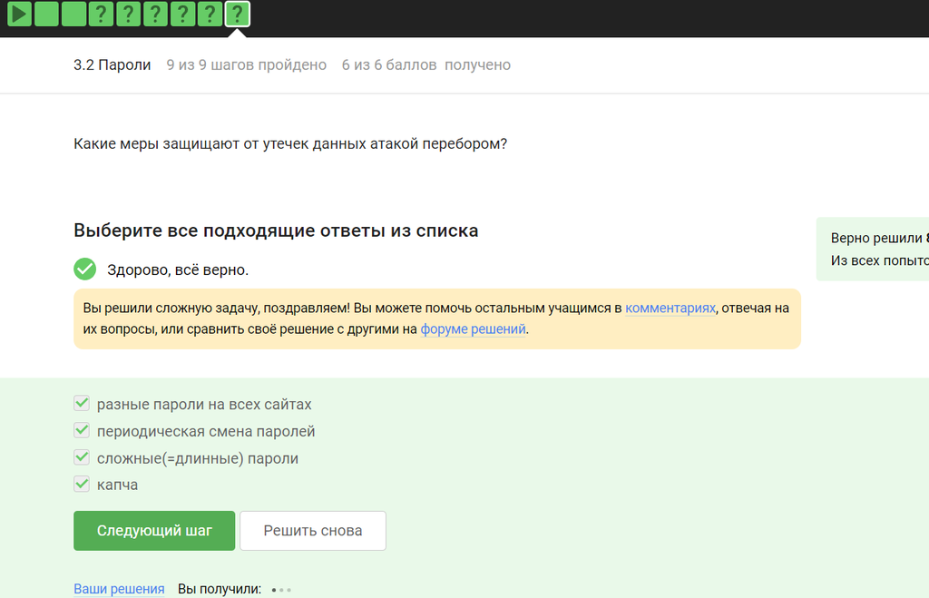

## Вопрос 3.3.1

Фишинговые ссылки очень похожи на ссылки известных сервисов, но с некоторыми отличиями

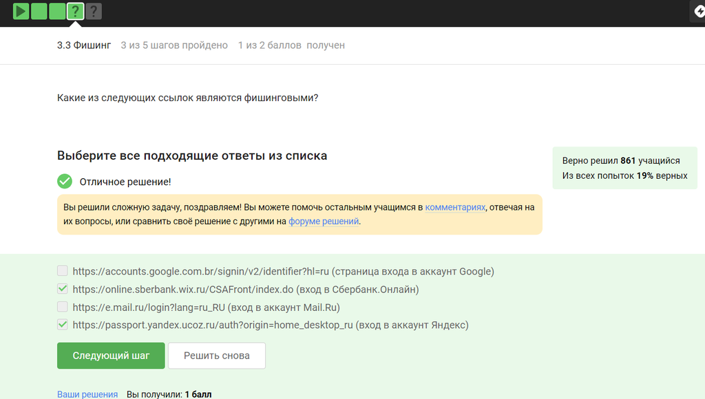

## Вопрос 3.3.2

Да, может, например, если пользователя со знакомым адресом взломали

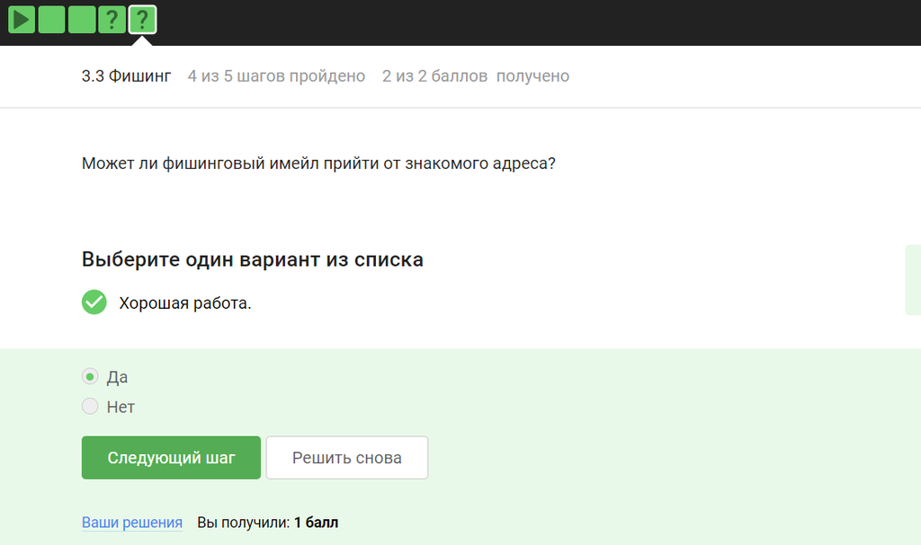

## Вопрос 3.4.1

Ответ дан в соответствии с определением

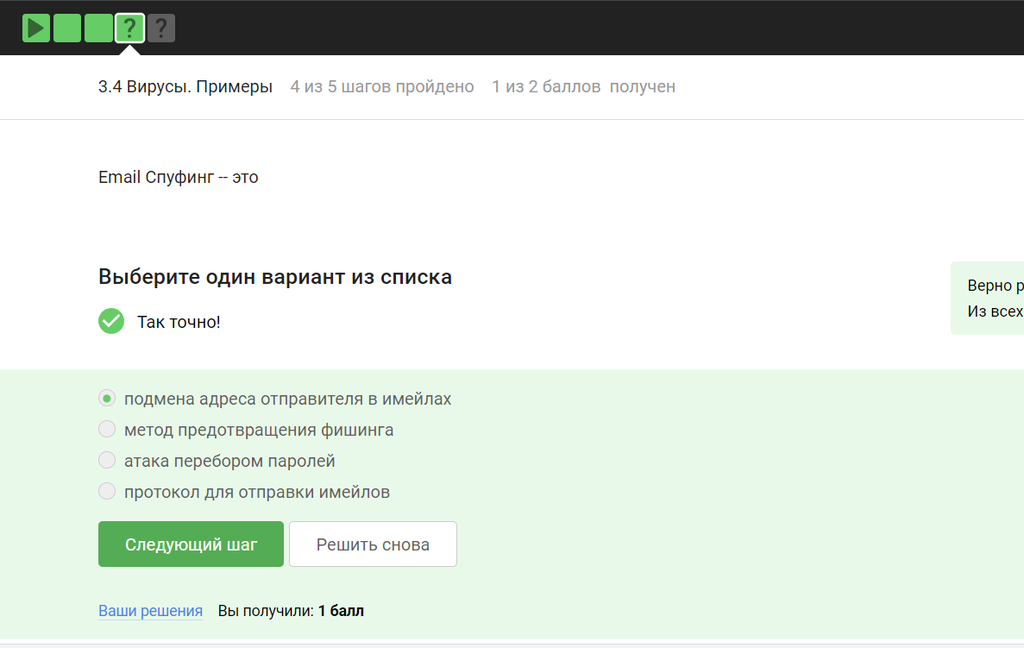

## Вопрос 3.4.2

Трояны маскируются под обычную программу

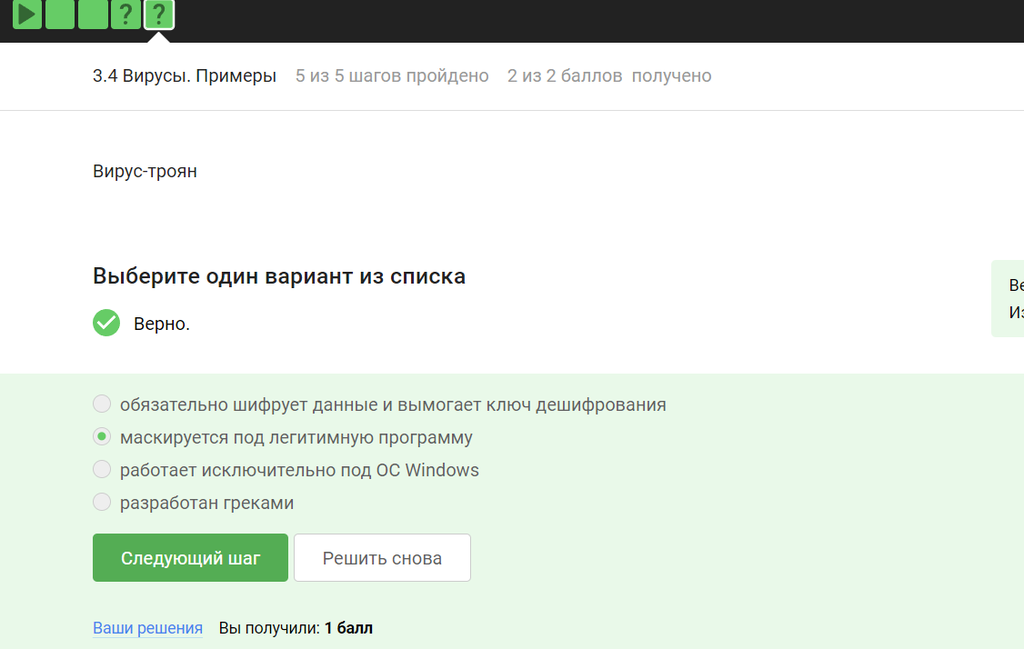

## Вопрос 3.5.1

При установке первого сообщения отправителем формируется ключ шифрования

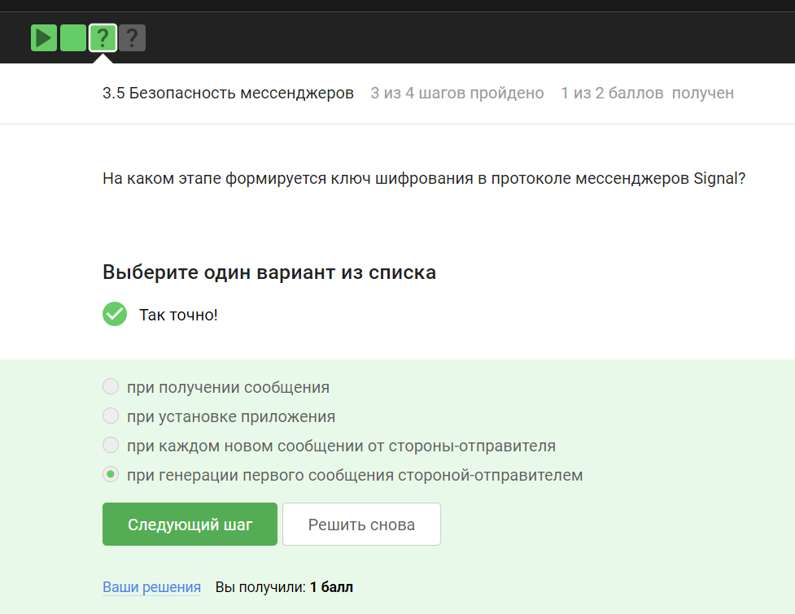

## Вопрос 3.5.2

Суть сквозного шифрования состоит в том, что сообщения передаются по узлам связи в зашифрованном виде

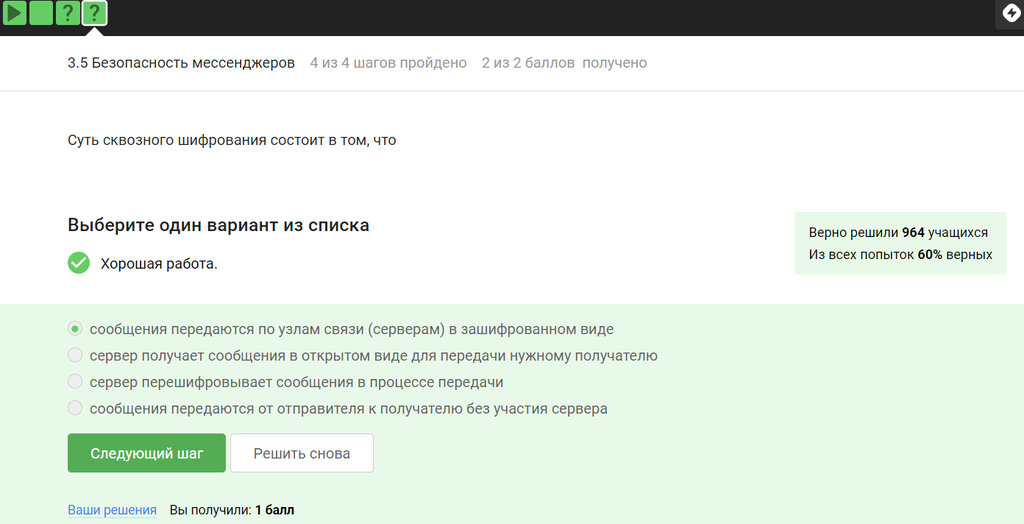

## Вывод

Был пройден второй блок курса “Основы кибербезопасности”, изучены правила хранения паролей и основная информация о вирусах